# Experiment3: More Airline Data

2023-09-13

# Packages

```r
library(tidyverse)
library(nycflights13)
library(here)
library(janitor)
```

```r
library(ggplot2)
```

# Get data from the online source.

Save the download to your data_raw directory. It will be a zipfile,, but that will be OK. Don’t change the name of the zipfile.

## Load the BOT data

We take advantage of the ‘here’ package to get the path to the file that we stored. We also may note that inside the zipfile is a csv file. We will read the csvfile.

```r
thisfile <- here("data_raw", "DL_SelectFields.zip")

df2022 <- read_csv(thisfile) |> clean_names()
```

## Subsetting to data of interesst

Load in all BOT data needed

```r
thisfile <- here("data_raw",  "DL_SelectFields_2017.zip")
df2017 <- read_csv(thisfile) |> clean_names()
thisfile <- here("data_raw",  "DL_SelectFields_2018.zip")
df2018 <- read_csv(thisfile) |> clean_names()
thisfile <- here("data_raw",  "DL_SelectFields_2019.zip")
df2019 <- read_csv(thisfile) |> clean_names()
thisfile <- here("data_raw",  "DL_SelectFields_2020.zip")
df2020 <- read_csv(thisfile) |> clean_names()
thisfile <- here("data_raw",  "DL_SelectFields_2021.zip")
df2021 <- read_csv(thisfile) |> clean_names()
thisfile <- here("data_raw", "DL_SelectFields_2022.zip")
df2022 <- read_csv(thisfile) |> clean_names()
thisfile <- here("data_raw", "DL_SelectFields_2023.zip")
df2023 <- read_csv(thisfile) |> clean_names()
```

Here, we will bind all data from 2017-2023 together

```r
dfc=df2017 |>
  bind_rows(df2018)|>
  bind_rows(df2019)|>
  bind_rows(df2020)|>
  bind_rows(df2021)|>
  bind_rows(df2022)|>
  bind_rows(df2023)
```

First, we will narrow the scope of our search to just passenger flights going and coming from the LaGuardia Airport in NYC.

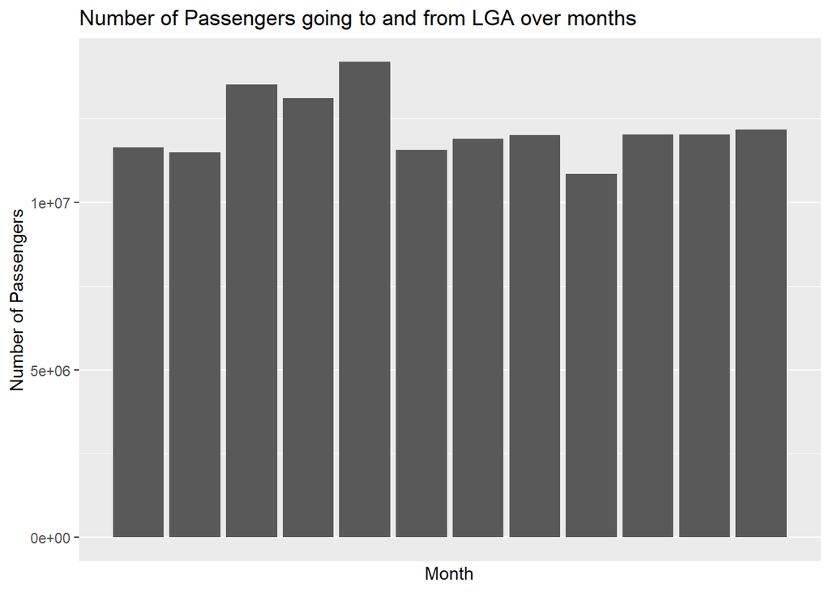

```r
dfLGA = dfc |>
  filter(origin == "LGA" | dest == "LGA", passengers > 0)

months_date = c("January", "February", "March", "April", "May", "June", "July", "August", "September", "October", "November", "December")

dfLGA |>
  ggplot(aes(month)) +
  geom_bar(aes(weight = passengers))+ labs(title = "Number of Passengers going to and from LGA over months", x = "Month", y = "Number of Passengers") + scale_x_discrete(labels= months_date)
```

Then, we will break up the passengers by year. Each column represents the number of passengers who flew through LGA that year.

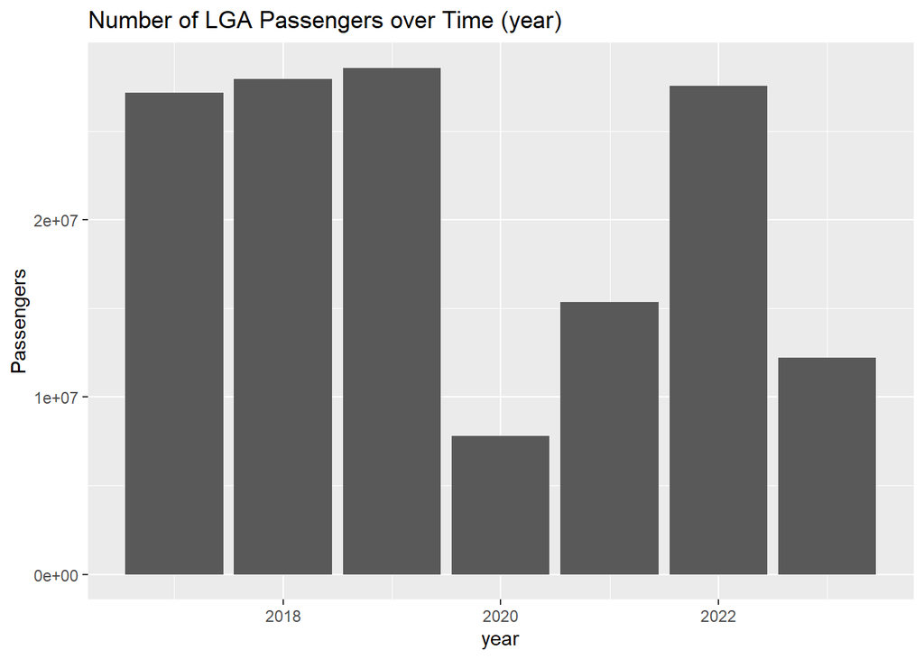

```r
dfLGA |>
  ggplot(aes(year)) +
  geom_bar(aes(weight = passengers)) +
  labs(title = "Number of LGA Passengers over Time (year)", y = "Passengers")
```

# Passengers by month from 2017 to 2023

This graph presents a break-down of the previous graph. Each bar represents the number of passengers that flew in a given month for that year, starting from 2017.

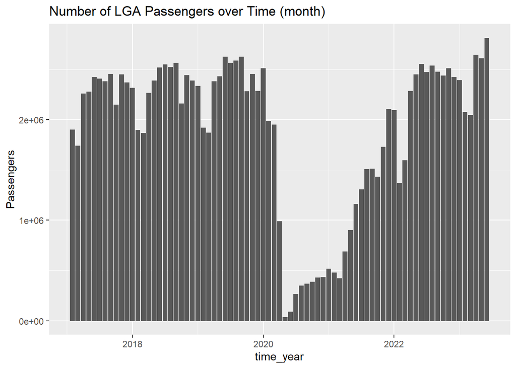

```r
dfLGA |>
  mutate(time_year = year + month / 12) |>
  ggplot(aes(x = time_year)) + geom_bar(aes(weight = passengers)) +
  labs(title = "Number of LGA Passengers over Time (month)", y = "Passengers")
```

This graph considers the flights between LGA and MIA.

```r
dfLGA_to_MIA = dfLGA |>
  mutate(by_month = ym(str_c(year,"-",month))) |>
  filter(dest == "MIA" & origin == "LGA") |>
  group_by(origin, dest, by_month) |>
  summarise(passengers = sum(passengers))
dfMIA_to_LGA = dfLGA |>
  mutate(by_month = ym(str_c(year,"-",month))) |>
  filter(dest == "LGA" & origin == "MIA") |>
  group_by(origin, dest, by_month) |>
  summarise(passengers = sum(passengers))
```

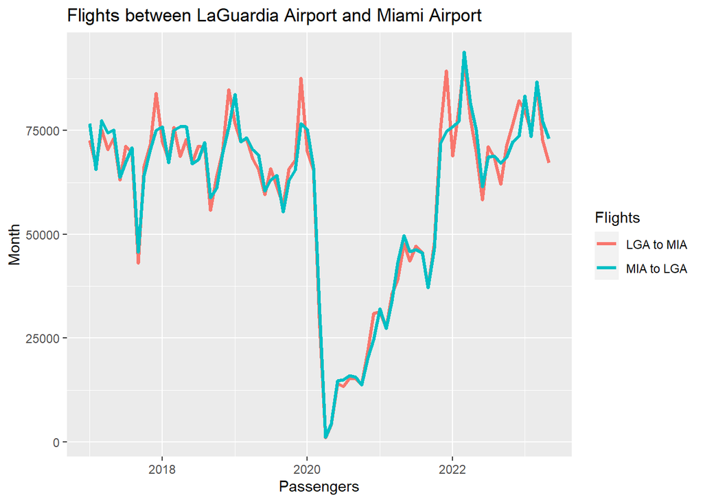

```r
ggplot() + geom_line(dfLGA_to_MIA, mapping = aes(x = by_month, y = passengers, color = "LGA to MIA"), size = 1.2) + geom_line(dfMIA_to_LGA, mapping = aes(x = by_month, y = passengers, color = "MIA to LGA"), size = 1.2) + labs(title = "Flights between LaGuardia Airport and Miami Airport", x = "Passengers", y = "Month") + labs(color = "Flights")
```

This graph shows the passengers that flew from LGA to MIA over the months from 2017 to 2023 compared to the amount of passengers that flew from MIA to LGA over the months from 2017 to 2023.

```r
dfLGA_MIA = dfLGA |>
  mutate(by_month = ym(str_c(year,"-",month))) |>
  filter(dest == "MIA" | origin == "MIA")|>
  group_by(origin, by_month) |>
  summarise(passengers = sum(passengers)) |>
  mutate(cum_pass = cumsum(passengers)) |>
  pivot_wider(names_from = origin, values_from = c("passengers", "cum_pass")) |>
  mutate(net_to_miami = passengers_LGA - passengers_MIA, cum_to_miami = cum_pass_LGA - cum_pass_MIA)
```

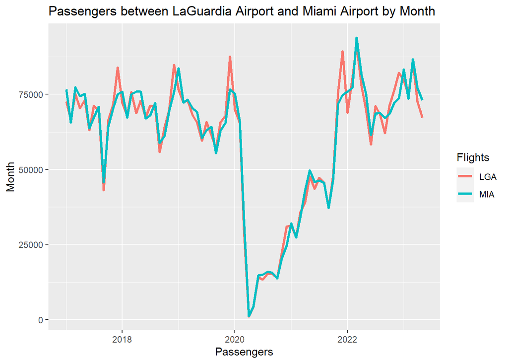

```r
ggplot() + geom_line(dfLGA_MIA, mapping = aes(x = by_month, y = passengers_LGA, color = "LGA"), size = 1.2) + geom_line(dfLGA_MIA, mapping = aes(x = by_month, y = passengers_MIA, color = "MIA"), size = 1.2) + labs(title = "Passengers between LaGuardia Airport and Miami Airport by Month", x = "Passengers", y = "Month") + labs(color = "Flights")
```

A graph that plots a CUMMULATIVE SUM of those monthly totals

```r
dfLGA_MIA_cum = dfLGA |>
  mutate(by_month = ym(str_c(year,"-",month))) |>
  filter(dest == "MIA" | origin == "MIA")|>
  group_by(origin, by_month) |>
  summarise(passengers = sum(passengers)) |>
  mutate(cum_pass = cumsum(passengers)) |>
  pivot_wider(names_from = origin, values_from = c("passengers", "cum_pass")) |>
  mutate(net_to_miami = passengers_LGA - passengers_MIA, cum_to_miami = cum_pass_LGA - cum_pass_MIA)
```

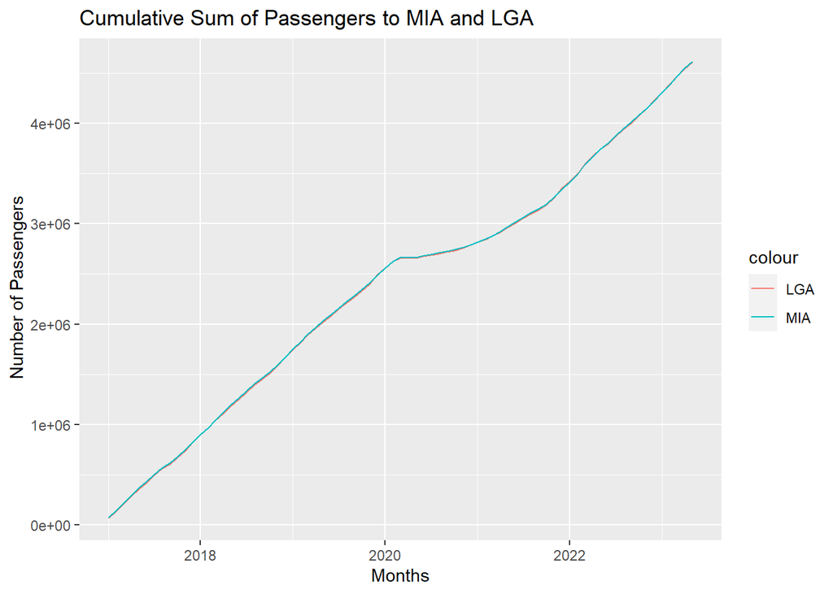

```r
ggplot() + geom_line(dfLGA_MIA_cum, mapping = aes(x = by_month, y = cum_pass_LGA, color = "LGA")) + geom_line(dfLGA_MIA_cum, mapping = aes(x = by_month, y = cum_pass_MIA, color = "MIA")) + labs(title = "Cumulative Sum of Passengers to MIA and LGA", x = "Months", y = " Number of Passengers")
```

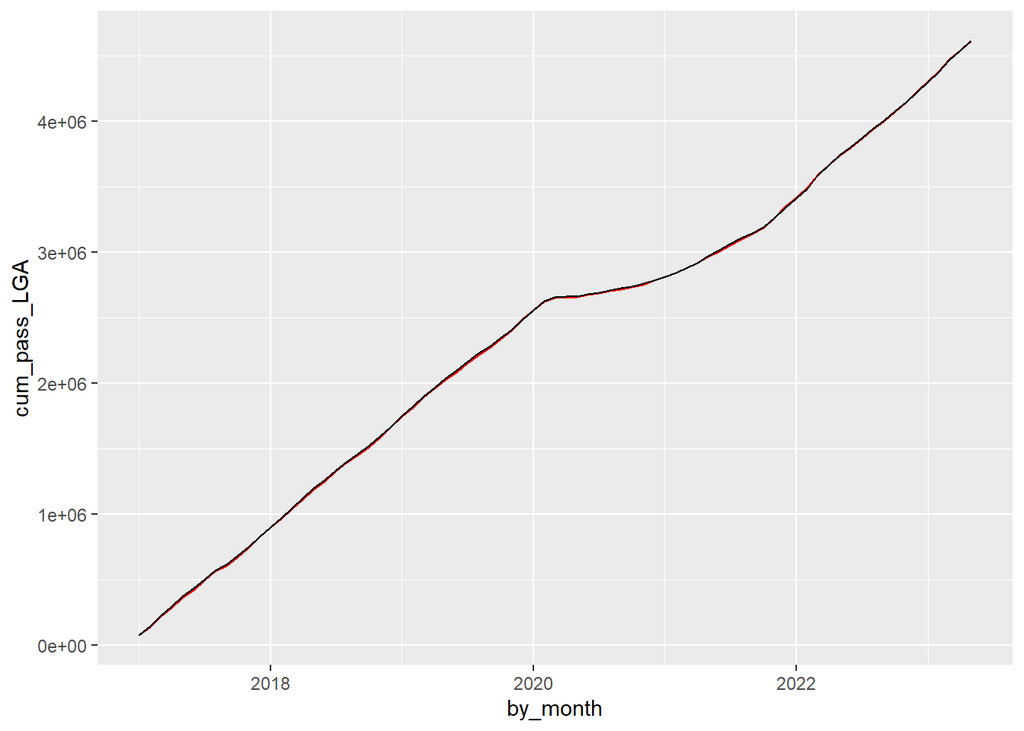

```r
ggplot() + geom_line(dfLGA_MIA_cum, mapping = aes(x = by_month, y = cum_pass_LGA), color = "red") + geom_line(dfLGA_MIA_cum, mapping = aes(x = by_month, y = cum_pass_MIA))
```

This graph shows the net amount of passengers to Miami over time.

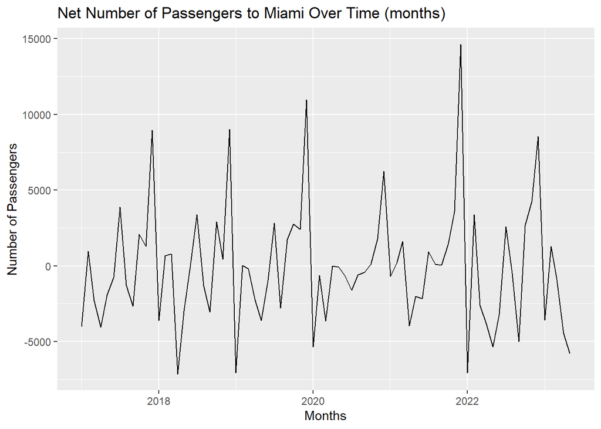

```r
ggplot() + geom_line(dfLGA_MIA_cum, mapping = aes(x = by_month, y = net_to_miami)) +labs(title = "Net Number of Passengers to Miami Over Time (months)", x = "Months", y = "Number of Passengers")
```

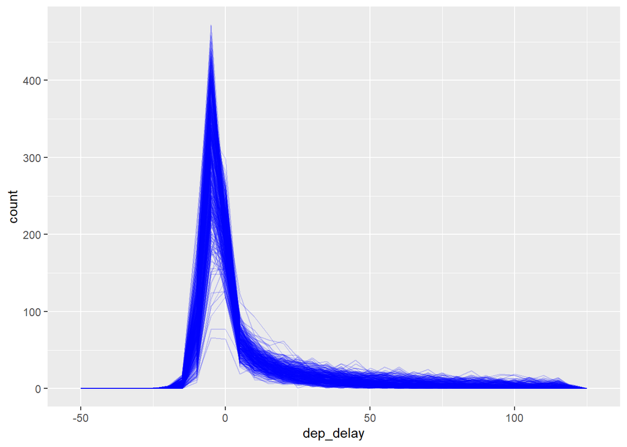

```r
flights |>
  filter(dep_delay < 120) |>
  ggplot(aes(x = dep_delay, group = interaction(day, month))) +
  geom_freqpoly(binwidth = 5, alpha = 1/5, color = "Blue" )
```